# MEE 621 - Activity 9 Models

### Explore other methods for visualising the distribution of per continent. You might want to try the ggbeeswarm package, which provides similar methods for avoiding overlaps as jitter, but uses deterministic methods.

-visualizing of linear model

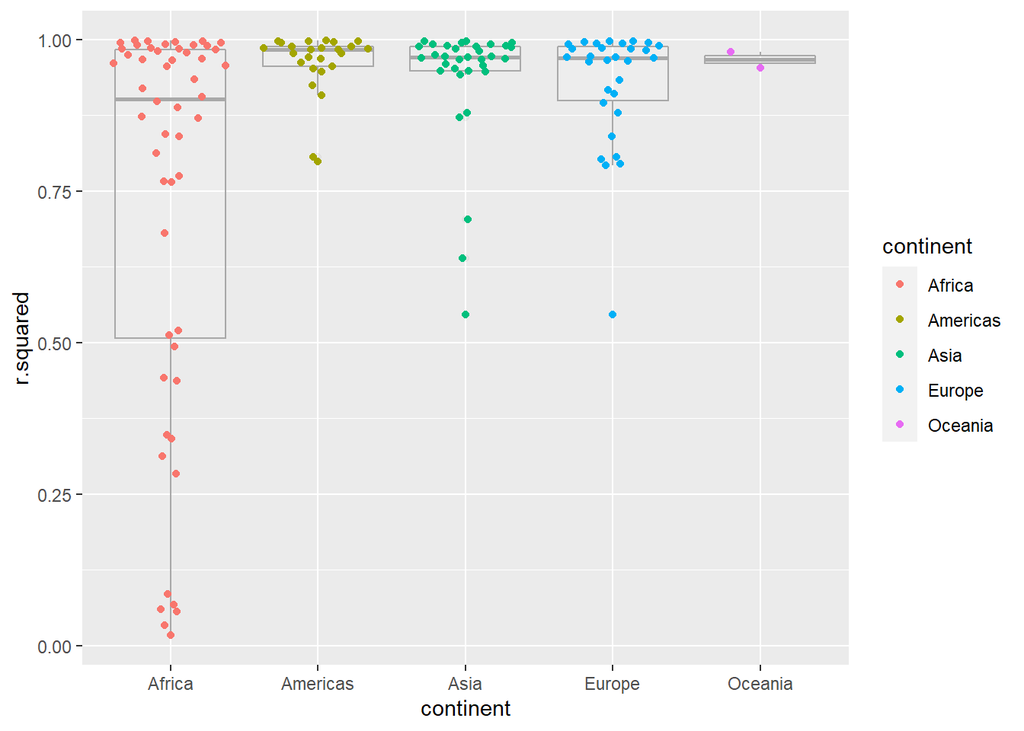

```r
by_country3_quad %>%
  unnest(glance_mod) %>%
  ggplot(aes(x = continent, y = r.squared, colour = continent))+
  geom_boxplot(alpha = 0.1, colour = "dark grey")+
  ggbeeswarm::geom_quasirandom()
```

- I like geom_quasirandom() the best as an overlay on boxplot, it keeps things centered and doesn’t have the gravitational pull affect that makes geom_beeswarm() become a little misaligned, it also works well here over geom_jitter() as the points stay better around their true value

### To create the last plot (showing the data for the countries with the worst model fits), we needed two steps: we created a data frame with one row per country and then semi- joined it to the original dataset. It’s possible to avoid this join if we use unnest() instead of unnest(.drop = TRUE) . How?

- First, filter by r.squared and then unnest

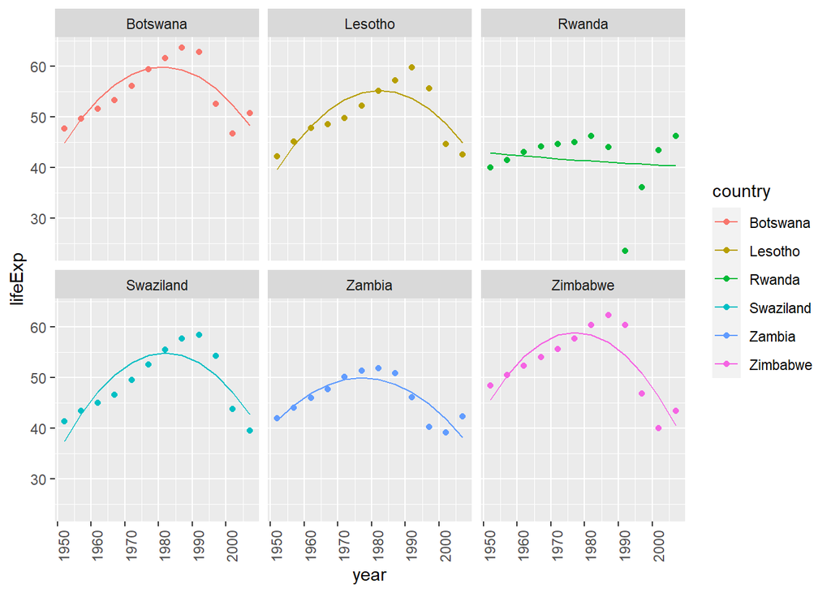

```r
by_country3_quad %>%
  mutate(data_preds = purrr::map2(data_cent, mod_quad, add_predictions)) %>%
  unnest(glance_mod) %>%
  mutate(bad_fit = r.squared < 0.25) %>%
  filter(bad_fit) %>%
  unnest(data_preds) %>%
  ggplot(aes(x = year, group = country))+
  geom_point(aes(y = lifeExp, colour = country))+
  geom_line(aes(y = pred, colour = country))+
  facet_wrap(~country)+
  theme(axis.text.x = element_text(angle = 90, hjust = 1))
```

Or, join all graphs together

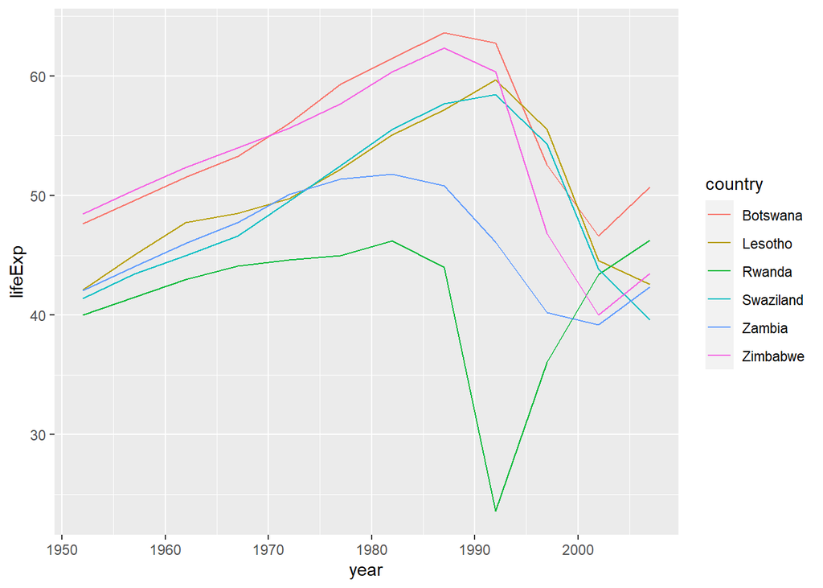

```r
gapminder %>%
  group_by(country, continent) %>%
  nest() %>%
  mutate(model = map(data, ~lm(lifeExp ~ year, .))) %>%
  mutate(glance = map(model, broom::glance)) %>%
  unnest(glance) %>%
  unnest(data) %>%
  filter(r.squared < 0.25) %>%
  ggplot(aes(year, lifeExp)) +
  geom_line(aes(color = country))
```

# CONCLUSIONS

While doing the activities, I have learned the following three main categories:

- how models work mechanistically, focusing on the important family of linear models. You’ll learn general tools for gaining insight into what a predictive model tells you about your data, focusing on simple simulated datasets.
- how to use models to pull out known patterns in real data. Once you have recognized an important pattern it’s useful to make it explicit in a model, because then you can more easily see the subtler signals that remain.
- how to use many simple models to help understand complex datasets. This is a powerful technique, but to access it you’ll need to combine modeling and programming tools.

**Basic modeling concepts:**

In the basic concept of models, I learned that the majority of modeling functions in R use a standard conversion from formulas to functions. I also encountered and seen its demonstration in visualizing models especially predictions and residuals. In R programming, predictive models are extremely useful for forecasting future outcomes and estimating metrics that are impractical to measure.Sometimes, It’s also useful to see what the model doesn’t capture, the so-called residuals that are left after subtracting the predictions from the data. Residuals are powerful because they allow us to use models to remove striking patterns so we can study the subtler trends that remain. In summary, I understand now how linear models worked, and learned some basic tools for understanding what a model is telling you about your data.

**Many models with `purrr` and `broom`:**

We were able to dive into nested data and list-columns. The data frames are in a list, so we were able to use `purrr::map()`. Here in this part, we dissected the general measurements of model quality when we used a different approach using the `broom` package. These ideas are a stretch for me as it somewhat high-level already just like using `broom::glance()` to extract some model quality metrics as well as `nest()` and ```unnest````.